# Code for Weekly Visits Summary for NFO Businesses

Maeve Givens

4/25/2020

The following document creates graphs based off of the weekly visits data in North Fair Oaks Businesses. The weekly visits data is based off a summary of visits from Safegraph.

## Data and Code Prep

This chunk loads the relevant packages.

```r
library(tidyverse)
library(tigris)
library(censusapi)
library(sf)
library(mapview)
library(plotly)
library(ggplot2)
library(esquisse)
library(dplyr)
library(shiny)

options(
  tigris_class = "sf",
  tigris_use_cache = T # This stores tigris loads somewhere on your machine for much faster personal loading.
)
```

This loads the NFO businesses data frame. It also loads the relevant NAICS sector codes and the naics codes for essential businesses.

```r
# SET your path here to the covid19analysis folder.
sg_path <- 'C:/Users/kfg3z/OneDrive/Documents/GitHub/covid19/'

NFO_places_path <- paste0(sg_path,'Givens_Maeve/NFO_places_Safegraph_visits1920.rds')

NFOplaces_orig <- readRDS(NFO_places_path)

naics_sector_codes <- read.csv(paste0(sg_path,'Givens_Maeve/naics_sector.csv'))

ca_essential_places <-read.csv(paste0(sg_path,'Givens_Maeve/ca_essential_designations_naics.csv'))
```

From the naics code, this section adds each businesses sector and business type description to the NFO business information. It also adds whether this business is designated as “essential” in California. NFO_places_by_sector simply serves as a data frame to understand the breakdown of businesses in NFO by industry and business type.

```r
NFOplaces_geo <- NFOplaces_orig %>%
  mutate(
    naics_sector = as.numeric(substr(as.character(naics_code),1,2))
  ) %>%
  left_join(
    naics_sector_codes, by="naics_sector"
  ) %>%
  left_join(ca_essential_places, by= "naics_code") %>%
  mutate(
    essential_service = ifelse(
      is.na(essential_service),
      'Not Essential',
      "Essential Service"
    )
  )

NFO_places_by_sector <-
  NFOplaces_geo %>%
  st_drop_geometry %>%
  group_by(industry_title, description, essential_service) %>%
  summarize(
    count = n()
    )
```

## Graph 1: Percent Change in Visits to NFO Businesses in the 4th Week of March from 2019 to 2020

This section highlights an example of visualizing the percent change in visits to businesses. This example uses the percent change in NFO businesses in the fourth week of march (week 4) between 2019 and 2020. Visits marked as NA were outliers. They were marked as outliers for the purposes of visualization as well as potential inconsistencies in the data.

```r
NFOplaces20_week4 <- NFOplaces_geo %>%
  dplyr::select(c('location_name','street_address','week4_visits19','week4_visits20','perc_chg_week4','essential_service','description')) %>%
  mutate(
    perc_chg_week4 = ifelse(
      perc_chg_week4 > 2,
      NA, #anything marked as NA is an outlier
      perc_chg_week4
    )
  )

#This maps week 4 percent change for all businesses.
mapview(NFOplaces20_week4 ,zcol = 'perc_chg_week4', layer.name = "% Change in  Visits in 4th Week of March")
```

[interactive chart not shown]

```r
#This maps week 4 percent change for essential services.
# NFOplaces20_week4_essential <-
#   NFOplaces20_week4 %>%
#   filter(essential_service %in% "Essential Service")
#
# mapview(NFOplaces20_week4_essential ,zcol = 'perc_chg_week4', layer.name = "% Change in  Visits in 4th Week of March for Essential Businesses")
#
# #This maps week 4 percent change for non-essential services.
# NFOplaces20_week4_non_essential <-
#   NFOplaces20_week4 %>%
#   filter(essential_service %in% "Not Essential")
#
# mapview(NFOplaces20_week4_non_essential ,zcol = 'perc_chg_week4', layer.name = "% Change in  Visits in 4th Week of March for Non-Essential Businesses")
```

## Graph 2: Median Percent Change in Visits to NFO Retail Trade Businesses

The next section highlights a time series of how Retail trade industry in NFO has been impacted. It shows the median percent change in visits as compared to 2019 in the two sectors in essential and non essential businesses.

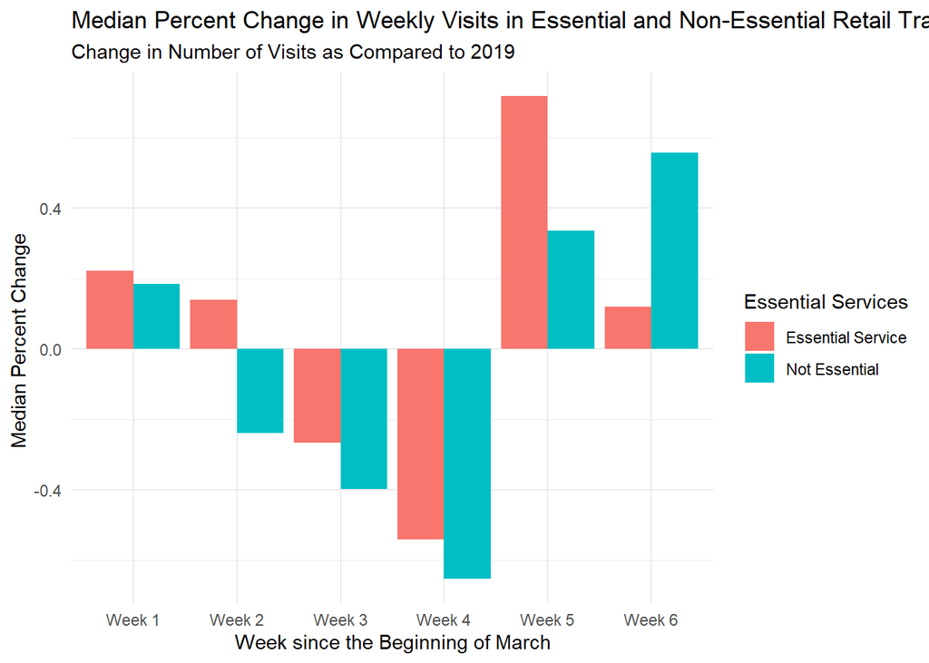

```r
#first we need to reorganize the data so that the dataset has a week variable and the number .

NFO_retail_trade_perc_chg_plot <- NFOplaces_geo %>%
  st_drop_geometry %>%
  filter(industry_title %in% "Retail Trade") %>%
  dplyr::select(c('location_name','essential_service','perc_chg_week1':'perc_chg_week6')) %>%
  gather(key = "week_ID", value = "perc_chg", c(perc_chg_week1:perc_chg_week6))%>%
  mutate(
    week = case_when(
      week_ID %in% "perc_chg_week1" ~ "Week 1",
      week_ID %in% "perc_chg_week2" ~ "Week 2",
      week_ID %in% "perc_chg_week3" ~ "Week 3",
      week_ID %in% "perc_chg_week4" ~ "Week 4",
      week_ID %in% "perc_chg_week5" ~ "Week 5",
      week_ID %in% "perc_chg_week6" ~ "Week 6",
    )
  ) %>%
  group_by(essential_service, week) %>%
  summarise(
    perc_change = median(perc_chg)
  )


ggplot(NFO_retail_trade_perc_chg_plot) +
 aes(x = week, fill = essential_service, group = essential_service, weight = perc_change) +
 geom_bar(position = "dodge") +
 scale_fill_hue() +
 labs(x = "Week since the Beginning of March", y = "Median Percent Change ", title = "Median Percent Change in Weekly Visits in Essential and Non-Essential Retail Trade Businesses in NFO", subtitle = "Change in Number of Visits as Compared to 2019", fill = "Essential Services") +
 theme_minimal()
```

## Graph 3: Changes in Weekly Visits to NFO Grocery Stores

The next section creates a graph of the number of visits to NFO grocery stores since the start of March 2020.

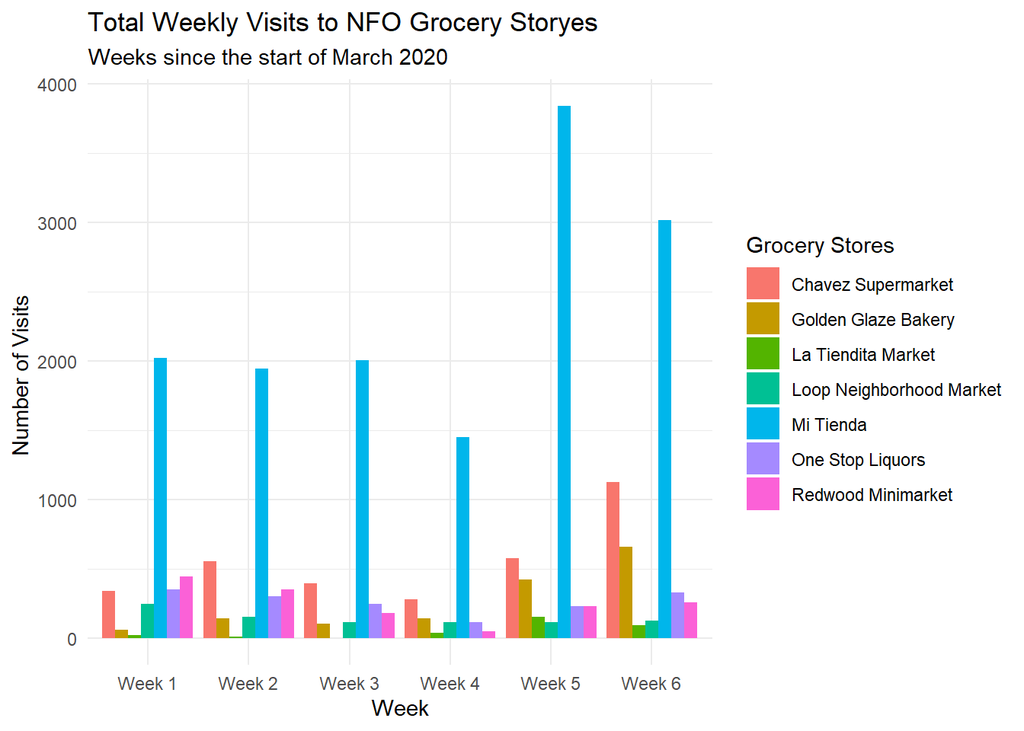

```r
#first we need to reorganize the data so that the dataset has a week variable and the number .

NFO_grocery_visits <- NFOplaces_geo %>%
  st_drop_geometry %>%
  filter(description %in% "Supermarkets and Other Grocery (except Convenience) Stores") %>%
  dplyr::select(c('location_name','week1_visits20':'week6_visits20')) %>%
  gather(key = "week_ID", value = "total_visits", c(week1_visits20:week6_visits20)) %>%
  mutate(
    week = case_when(
      week_ID %in% "week1_visits20" ~ "Week 1",
      week_ID %in% "week2_visits20" ~ "Week 2",
      week_ID %in% "week3_visits20" ~ "Week 3",
      week_ID %in% "week4_visits20" ~ "Week 4",
      week_ID %in% "week5_visits20" ~ "Week 5",
      week_ID %in% "week6_visits20" ~ "Week 6",
    )
  ) %>%
  group_by(location_name, week) %>%
  summarise(
    visits = sum(total_visits)
  )



ggplot(NFO_grocery_visits) +
 aes(x = week, fill = location_name, weight = visits) +
 geom_bar(position = "dodge") +
 scale_fill_hue() +
 labs(x = "Week", y = "Number of Visits ", title = "Total Weekly Visits to NFO Grocery Storyes", subtitle = "Weeks since the start of March 2020", fill = "Grocery Stores") +
 theme_minimal()
```

## Graph 4: Changes in Weekly Visits to Small Businesses from 2019 to 2020

The following creates a base example of how to see the change in number of visits between 2019 and 2020 at a business in NFO. I chose to use “El Guanaco Mexican & Salvadorean Restaurant.” Week 7 and 8 did not have data in 2020 yet.

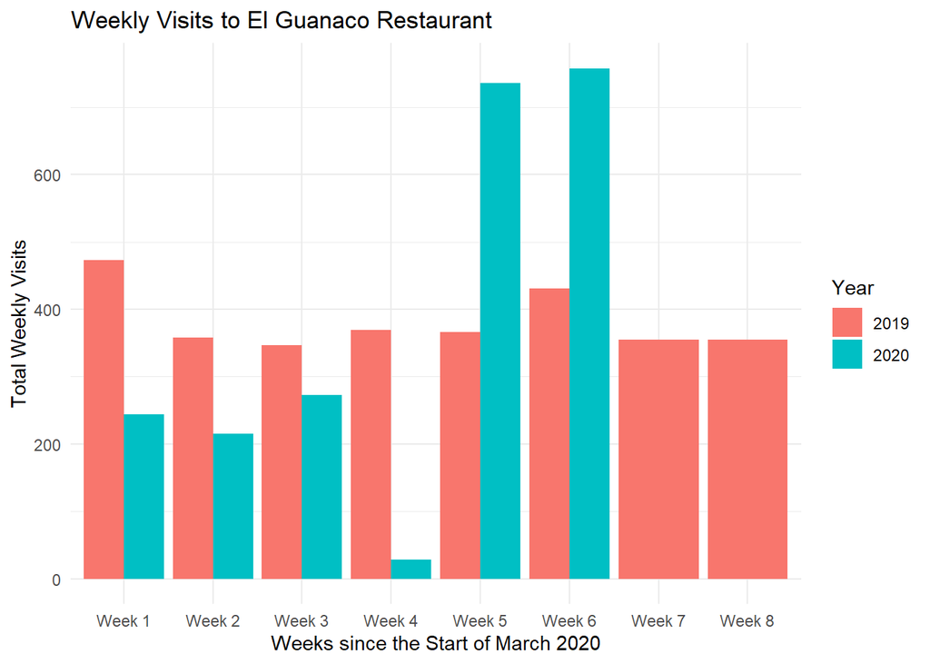

```r
ElGuanoco_visits <- NFOplaces_geo %>%
  st_drop_geometry %>%
  filter(location_name %in% "El Guanaco Mexican & Salvadorean Restaurant") %>%
  dplyr::select(c('week1_visits20':'week6_visits20','week1_visits19':'week8_visits19')) %>%
  gather(key = "week_ID", value = "total_visits") %>%
  mutate(
    week = case_when(
      week_ID %in% c("week1_visits19","week1_visits20") ~ "Week 1",
      week_ID %in% c("week2_visits19","week2_visits20") ~ "Week 2",
      week_ID %in% c("week3_visits19","week3_visits20") ~ "Week 3",
      week_ID %in% c("week4_visits19","week4_visits20") ~ "Week 4",
      week_ID %in% c("week5_visits19","week5_visits20") ~ "Week 5",
      week_ID %in% c("week6_visits19","week6_visits20") ~ "Week 6",
      week_ID %in% c("week7_visits19") ~ "Week 7",
      week_ID %in% c("week8_visits19") ~ "Week 8",
    ),
    year = case_when(
      week_ID %in%
        c("week1_visits20", "week2_visits20", "week3_visits20","week4_visits20", "week5_visits20", "week6_visits20") ~ "2020",
      week_ID %in%
        c("week1_visits19", "week2_visits19", "week3_visits19","week4_visits19", "week5_visits19", "week6_visits19","week7_visits19", "week8_visits19") ~ "2019"
    )
  ) %>%
  group_by(year, week) %>%
  summarise(
    visits = sum(total_visits)
  )

# This plots the visits to El Guanaco by week in 2019 and 2020

ggplot(ElGuanoco_visits) +
 aes(x = week, fill = year, weight = visits) +
 geom_bar(position = "dodge") +
 scale_fill_hue() +
 labs(x = "Weeks since the Start of March 2020", y = "Total Weekly Visits", title = "Weekly Visits to El Guanaco Restaurant ", fill = "Year") +
 theme_minimal()
```